# Practica_IV_APPLE

Laura Martínez González de Aledo

16/11/2020

### Variables:

- **Trimestres**
- **Ventas**

## Librerías

```r
require(forecast) # Transform to zoo data
require(xts) # Create a XTS object
require(ggplot2) # graphs
library(ggfortify) # graphs
```

## Datos

```r
# importar dataset
rawData <- read.csv2("./IngresosApple.csv", sep=";")
rawData
```

```
##    Trimestre Ingresos
## 1    Q2 2008     7980
## 2    Q3 2008     7561
## 3    Q4 2008    11520
## 4    Q1 2009    11880
## 5    Q2 2009     9084
## 6    Q3 2009     9734
## 7    Q4 2009    12207
## 8    Q1 2010    15683
## 9    Q2 2010    13499
## 10   Q3 2010    15700
## 11   Q4 2010    20343
## 12   Q1 2011    26741
## 13   Q2 2011    24667
## 14   Q3 2011    28571
```

[output cut: 24 more lines]

```r
# ajustar dataset para poder convertirlo a una serie temporal
rawVentas<-rawData$Ingresos
rawDate<-seq(as.Date("2008/04/01"), as.Date("2017/07/01"), by = "quarter")
```

Convrtimos nuestro Data Frame en una serie temporal.

```r
#Generate quarterly data
xVentas=to.quarterly(xVentas)

#Transform to zoo data (forecast package)
zVentas=as.zoo(xVentas$xVentas.Close)

#Change name
names(zVentas)="Ventas"
```

## Estacionariedad

Con el siguiente grafico podemos ver que se trata de una serie temporal no estacionaria ni en media ni en varianza:

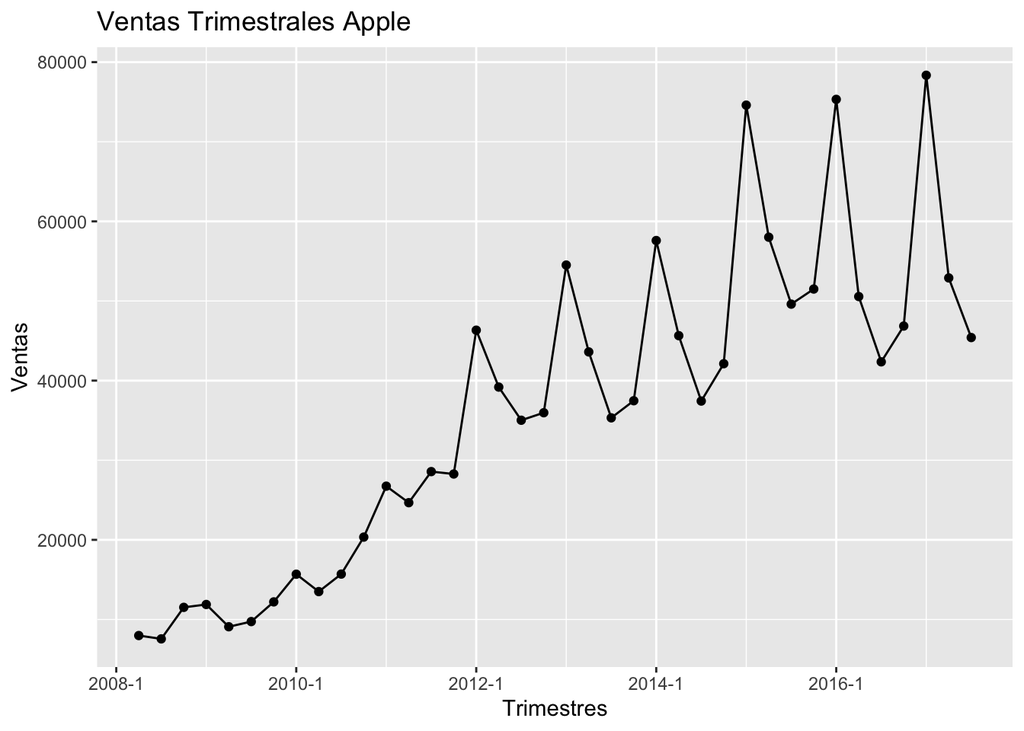

```r
df_new <- data.frame(value = as.vector(zVentas),
                     time = time(zVentas))
ggplot(df_new)+geom_point(aes(x=time,y=value))+geom_line(aes(x=time,y=value))+ylab("Ventas")+ggtitle("Ventas Trimestrales Apple")+xlab("Trimestres")
```

Vamos a tomar logaritmos para comprender mejor el conjunto de datos:

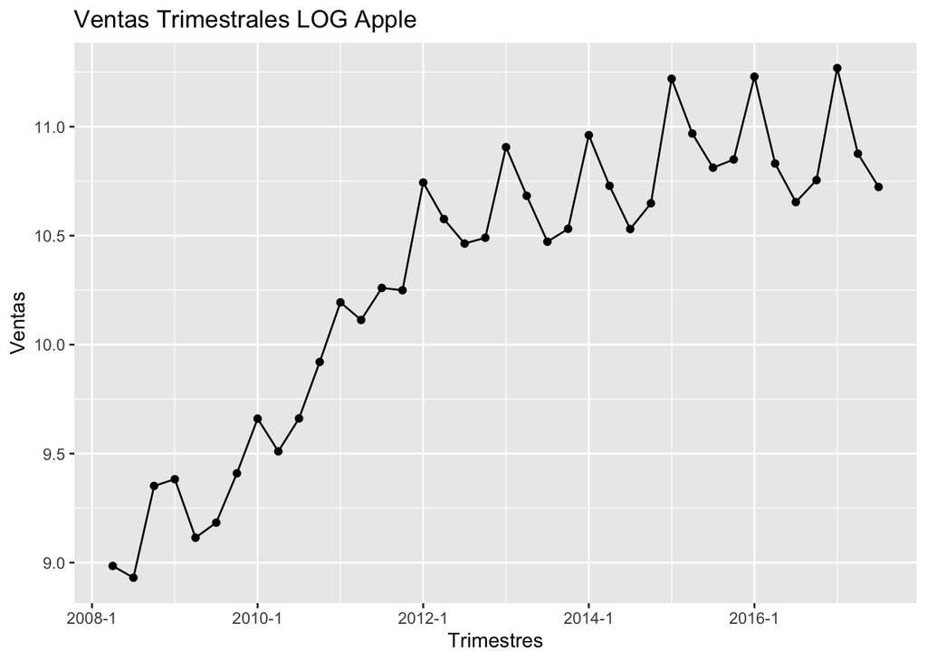

```r
# Log transformation
zlVentas=log(zVentas)
df_newl <- data.frame(value = as.vector(zlVentas),
                     time = time(zlVentas))
ggplot(df_newl)+geom_point(aes(x=time,y=value))+geom_line(aes(x=time,y=value))+ylab("Ventas")+ggtitle("Ventas Trimestrales LOG Apple")+xlab("Trimestres")
```

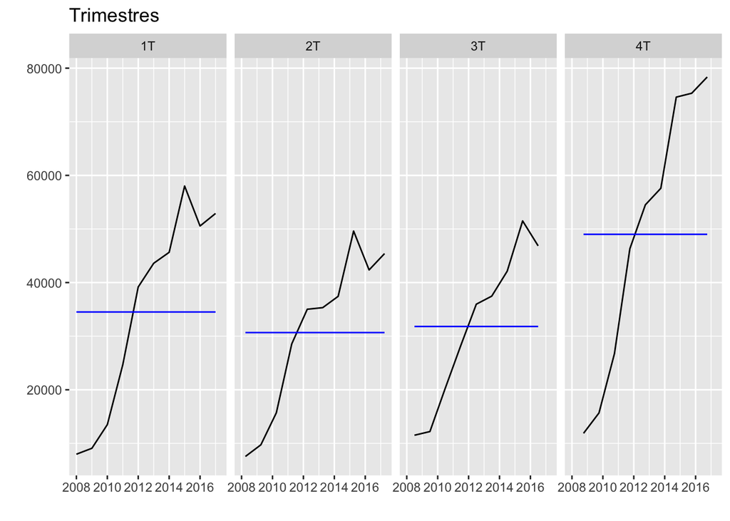

```r
#Transform to ts data
tsVentas=ts(coredata(zVentas), start = c(2008, 1), frequency = 4)
#Seasonal Plot
ggfreqplot(tsVentas,freq=4,nrow=1,facet.labeller=c("1T","2T","3T","4T"))+ggtitle("Trimestres")
```

A continuación vamos a estudiar los componentes de una serie temporal es decir, su tendencia, estacionalidad y si es irregular.

Con el grafico anterior podemos descubrir si los datos satisfacen todos los supuestos del modelado ARIMA, principalmente, la estacionariedad y la estacionalidad.

A continuación, debemos eliminar la parte no estacionaria de ARIMA. Para facilitar el análisis aquí, también eliminaremos la parte estacional de los datos.

Vamos a omitir tres últimos trimestres de 2017:

```
##         Ventas
## 2017 Q1  78351
## 2017 Q2  52896
## 2017 Q3  45408
```

Vamos a aplicar diferencias al modelo de manera que la autocorrelacion esté entre -0.5 y 0.5.

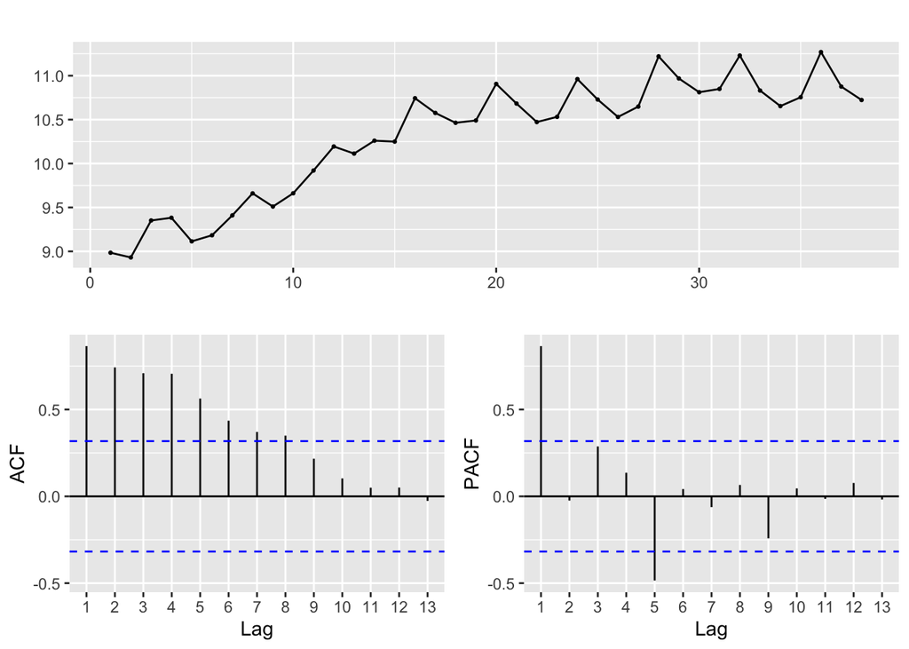

```r
#Difference
ggtsdisplay(zlVentas)
```

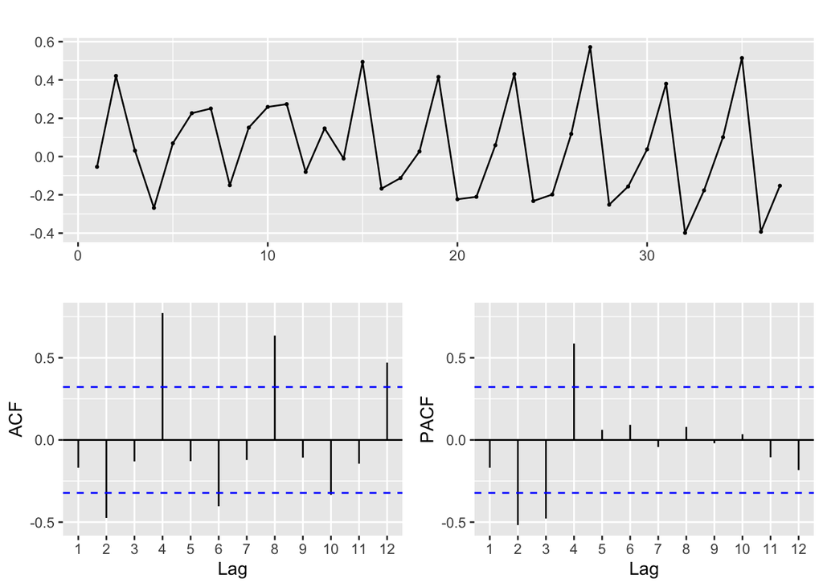

```r
ggtsdisplay(diff(zlVentas))
```

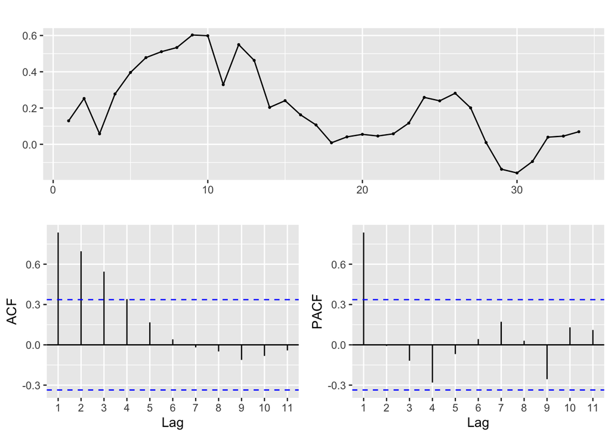

```r
ggtsdisplay(diff(zlVentas,4))
```

Las lineas azules discontinuas son las hipotesis. PACF es la autocorrelación parcial, elimina efectos indirectos es decir, lo que pasó hoy está relacionado con lo de ayer y lo de ayer con lo de antes de ayer. Por lo que lo que pasó hoy está relacionado con lo que pasó ayer de forma indirecta.

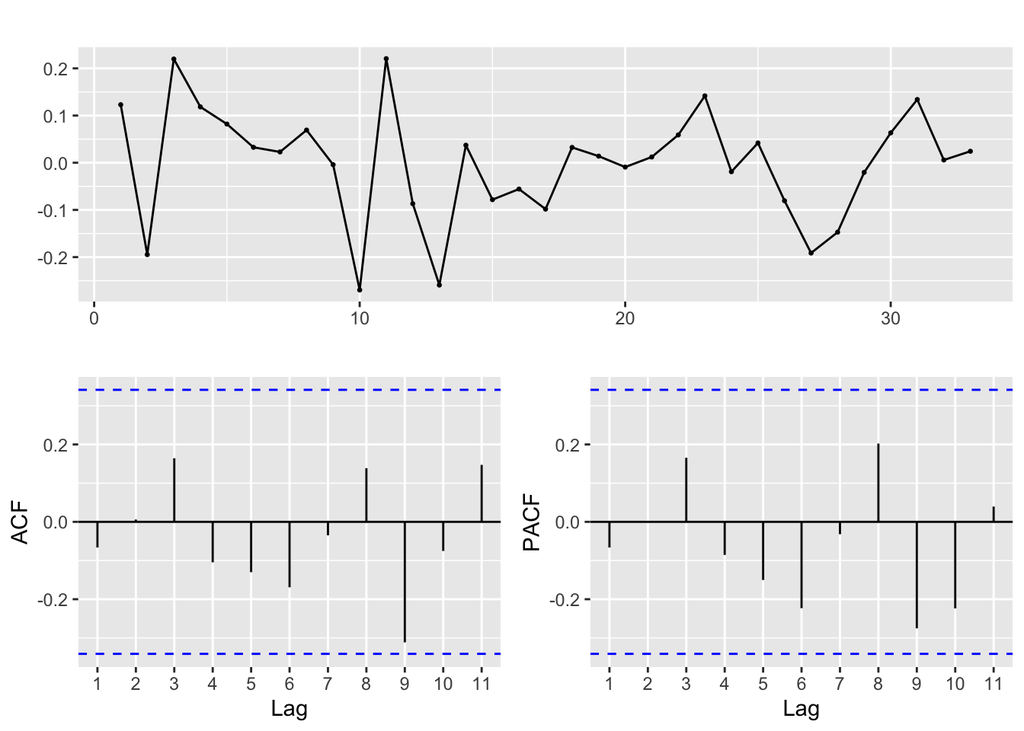

```r
ggtsdisplay(diff(diff(zlVentas,4),1))
```

## Forecast

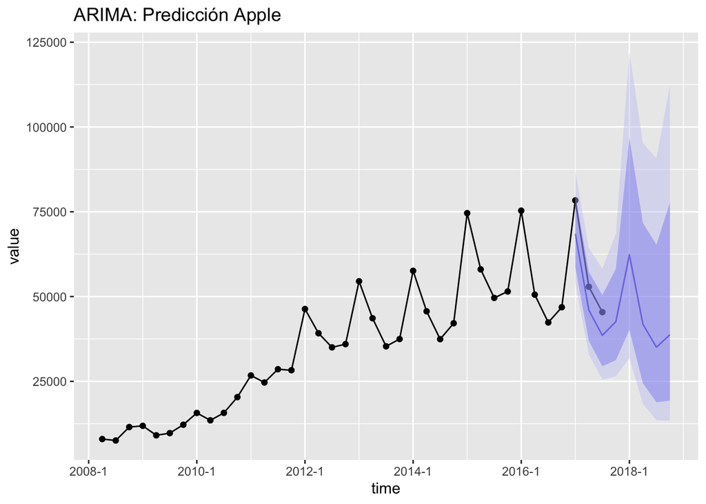

```r
fVentas.arima=forecast(fit1)

ggplot(df_new)+geom_point(aes(x=time,y=value))+geom_line(aes(x=time,y=value))+ geom_forecast(fVentas.arima,alpha=0.4)+ggtitle("ARIMA: Predicción Apple")
```

Podemos observar que la predicción de los ingresos de los trimestres que hemos excluido hemos un poco más baja que la real.

## Predicciones y precisiones

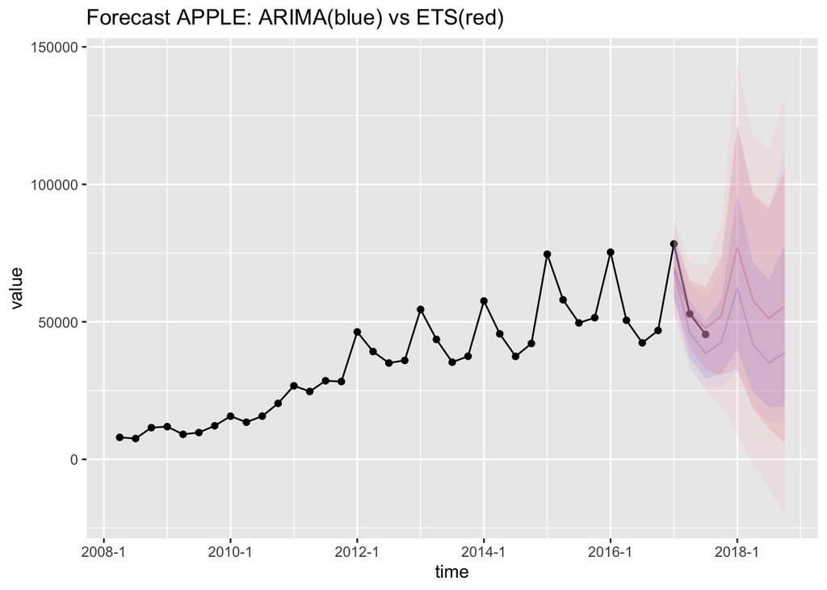

```r
#Plot
ggplot(df_new)+geom_point(aes(x=time,y=value))+
  geom_line(aes(x=time,y=value))+
  geom_forecast(fVentas.arima,color="blue",alpha=0.183, plot.conf = FALSE)+
  geom_forecast(fVentas.ets,color="red", alpha=0.183,plot.conf = FALSE)+
  ggtitle("Forecast APPLE: ARIMA(blue) vs ETS(red)")
```

```r
cbind(fVentas.arima$mean,fVentas.ets$mean)
```

```
##         fVentas.arima$mean fVentas.ets$mean
## 2017 Q1           68524.50         69929.62
## 2017 Q2           45993.21         53001.85
## 2017 Q3           38534.34         47699.77
## 2017 Q4           42622.67         52146.25
## 2018 Q1           62338.78         77165.52
## 2018 Q2           41841.40         57654.24
## 2018 Q3           35055.84         51287.35
## 2018 Q4           38775.11         55539.00
```

Como podemos observar el modelo ETS predice unas ventas más altas con mayor precisión.

## Bibliografía

- http://rstudio-pubs-static.s3.amazonaws.com/562743_b0859a1154aa4954a2779d9b492b8976.html
- https://www.diegocalvo.es/analisis-de-series-temporales-en-r-arima/
- http://halweb.uc3m.es/esp/Personal/personas/amalonso/esp/seriestemporales.pdf
- https://bookdown.org/content/2274/series-temporales.html